# Procesado de Señales e Imágenes Médicas

Ingeniería Biomédica

Ph.D. Pablo Eduardo Caicedo Rodríguez

2024-01-22

```r
#| echo: false
#| eval: true
#| output: false
#| label: r-packages-load

library("DiagrammeR")
library("reticulate")
library("xfun")
library("kableExtra")
library("tidyverse")
library("knitr")
library("cowplot")
library("ggfx")
knitr::opts_chunk$set(echo = FALSE)

def.chunk.hook <- knitr::knit_hooks$get("chunk")
knitr::knit_hooks$set(chunk = function(x, options) {
    x <- def.chunk.hook(x, options)
    ifelse(options$size != "normalsize", paste0("\n \\", options$size, "\n\n", x, "\n\n \\normalsize"), x)
})
```

# Part I: Probability and Statistics (Repaso)

## Events, Sample Space, Experiments

**Definition**

An **experiment** is a physical procedure that produces some kind of result.

**Definition**

An **event** is a set of experiment’s possible results.

**Consejo**

A **sample space** is the set of ALL possibles results of an experiment.

## Events, Sample Space, Experiments

- Graph
- Code
- Sample Space
- Result
- Dataset

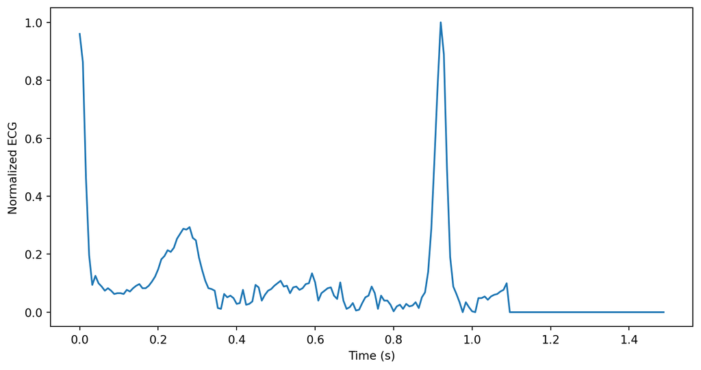

```python
data = np.genfromtxt(path_ecg+"/mitbih_train.csv", delimiter=",")
ecg1 = data[1, :-1]
time = np.array(range(0,len(ecg1)))/125
fig = plt.figure()
plt.plot(time, ecg1)
plt.xlabel("Time (s)")
plt.ylabel("Normalized ECG")
```

```python
print("Maximun Value: "+ str(ecg1.max()))
print("Minimun Value: "+ str(ecg1.min()))
```

```
Maximun Value: 1.0
Minimun Value: 0.0
```

```python
print(ecg1[np.random.choice(ecg1.shape[0], 1, replace=False)])
```

```
[0.07407407]
```

**Name:** ECG Heartbeat Categorization Dataset.

**URL:** https://www.kaggle.com/datasets/shayanfazeli/heartbeat?resource=download

## Probability Axioms

For the given events *A* and *B* that are in a sample space *S*:

**Axioms**

- $0 \leq P_r \left(A\right) \leq 1$
- $P_r\left(S\right) = 1$
- If $A \cap B = \emptyset$ then $P_r\left(A \cup B \right) = P_r \left(A\right) + P_r \left(B\right)$
- If $A \cap B \neq \emptyset$ then $P_r\left(A \cup B \right) = P_r \left(A\right) + P_r \left(B\right) - P_r\left(A \cap B \right)$
- $P_r\left(\bar{A}\right) = 1-P_r \left(A\right)$
- If $A\subset B$ then $P_r \left(A\right)\leq P_r \left(B\right)$
- $P_r \left(A|B\right)=\frac{P_r \left(A\cap B\right)}{P_r \left(B\right)}$

## Random Variable

**Definition**

A random variable is a real valued function of the elements of a sample space, *S* . Given an experiment, *E* , with sample space, *S*, the random variable maps each possible outcome of *E*.

**Definition**

The probability mass function (PMF), $P_X\left(x\right)$, of a random variable, *X*, is a function that assigns a probability to each possible value of the random variable, *X*.

## Random Variable

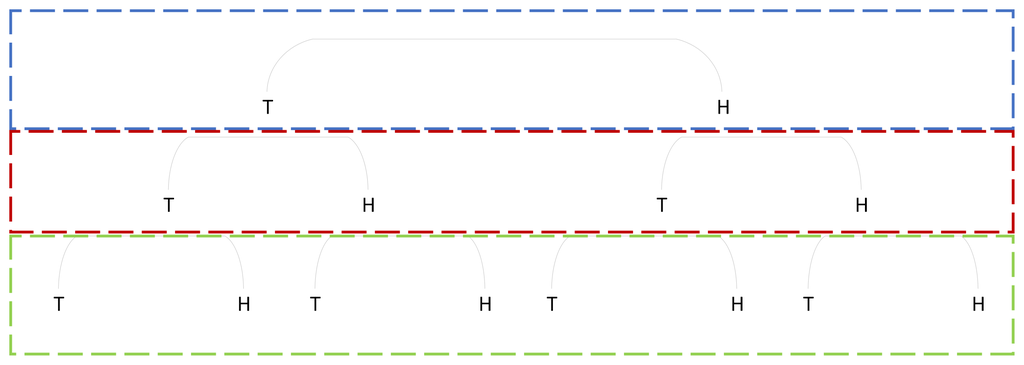

## Random Variables

### Conditions

**Discrete**

$$\sum_{\chi \in X}P_X\left(\chi \right) = 1$$

**Continuous**

$$\int_{-\infty}^{\infty}P_X\left(\chi \right)d\chi = 1$$

## Random Variables

### Expected Values

**Discrete**

$$\mu = \sum_{\chi \in X}\chi P_X\left(\chi \right)$$

**Continuous**

$$\mu=\int_{-\infty}^{\infty}\chi P_X\left(\chi \right)d\chi$$

## Random Variables

### Variance

**Discrete**

$$\sigma^2 = \sum_{\chi \in X}\left(\chi - \mu \right)^2 P_X\left(\chi \right)$$

**Continuous**

$$\sigma^2 = \int_{-\infty}^{\infty}\left(\chi - \mu \right)^2 P_X\left(\chi \right)d\chi$$

## PDF Estimation

- Graph
- Code
- Exp. Value
- Variance

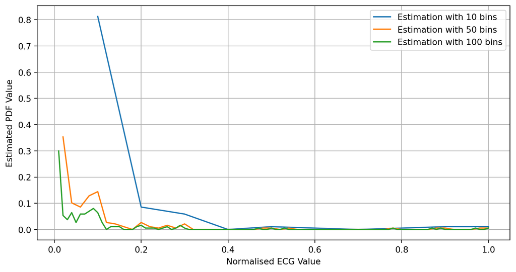

```python
counts01, bin_edges01 = np.histogram(ecg1, bins=10, density=True)
counts02, bin_edges02 = np.histogram(ecg1, bins=50, density=True)
counts03, bin_edges03 = np.histogram(ecg1, bins=100, density=True)
fig01=plt.figure()
plt.plot(bin_edges01[1:], counts01/sum(counts01), label="Estimation with 10 bins")
plt.plot(bin_edges02[1:], counts02/sum(counts02), label="Estimation with 50 bins")
plt.plot(bin_edges03[1:], counts03/sum(counts03), label="Estimation with 100 bins")
plt.legend()
plt.grid()
plt.xlabel("Normalised ECG Value")
plt.ylabel("Estimated PDF Value")
```

[output not shown]

[output not shown]

[figure not shown]

https://pacaicedo.github.io